# 2021 Q

### Poker PT2 2.0

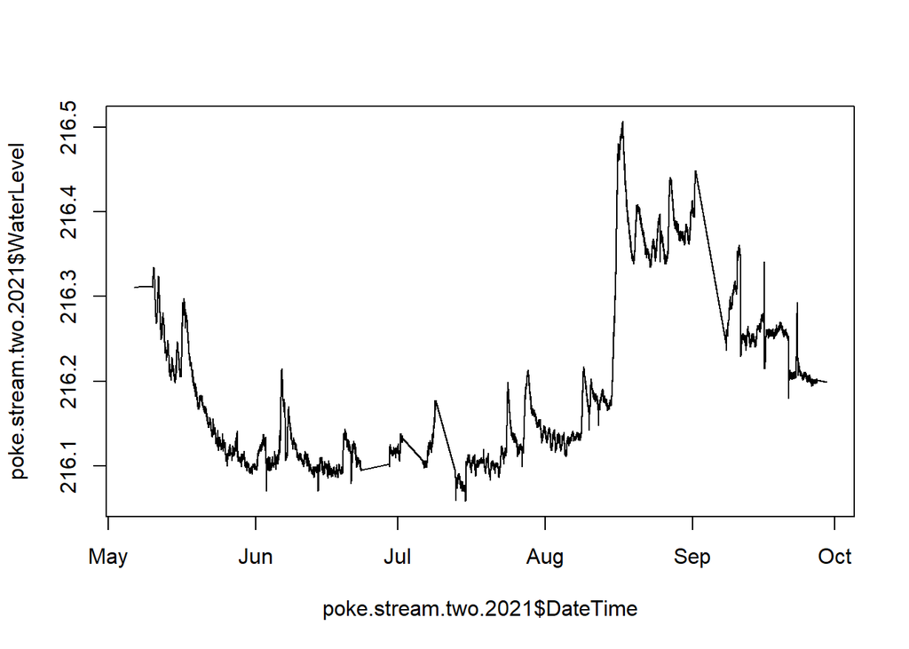

1) Removed beaver dam raise in water level in the beginning, middle of July and beginning of September 2) check the middle of August

## Export PT data to csv in DoD_Discharge->PT_data->2021

### Raw Rating curve Poker PT1

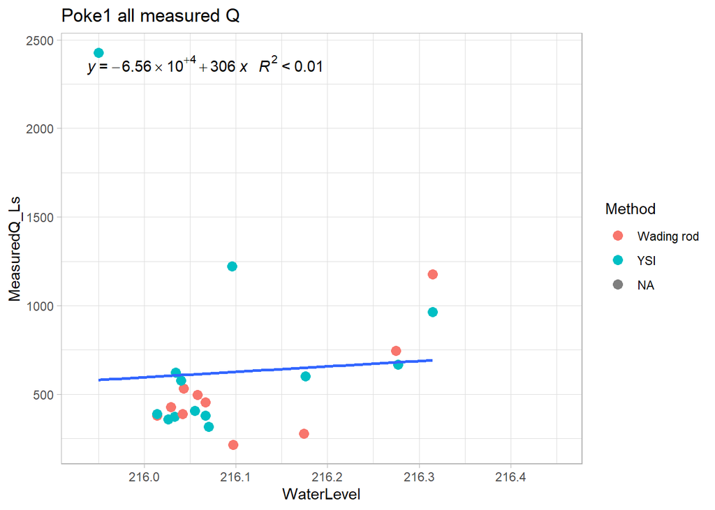

Will remove high YSI

### Rating curve Poker PT1 2.0

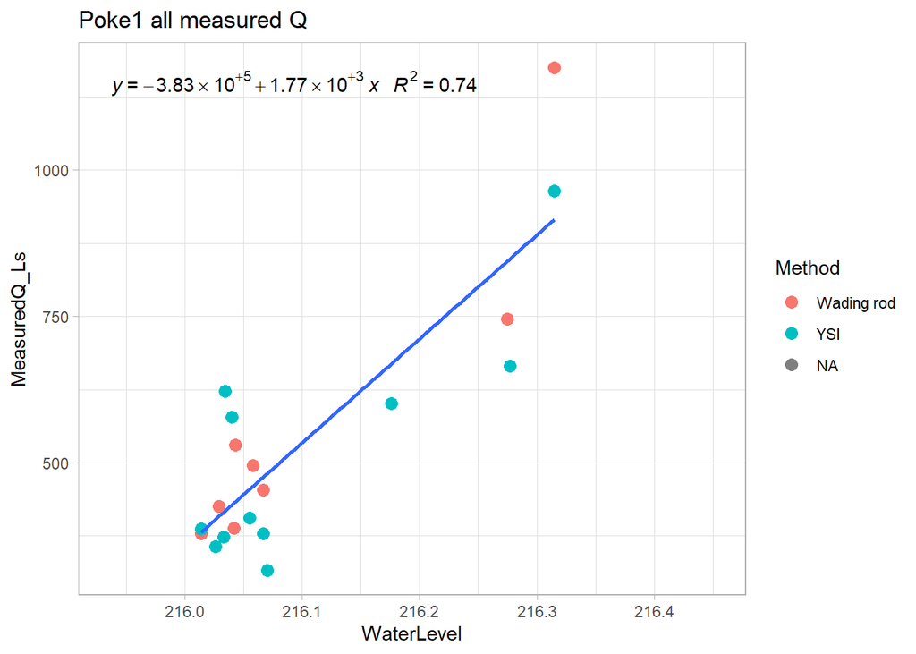

1) Removed highest YSI and 2) Removed lowest Wading rods

### Raw Rating curve Poker PT2

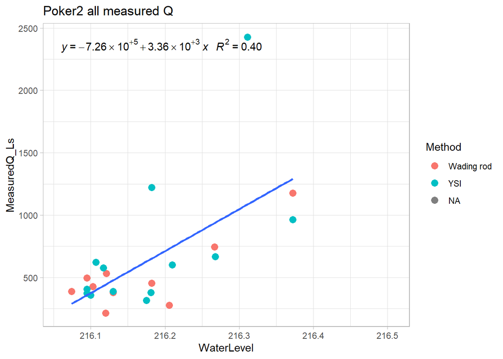

will remove highest YSI and lowest wading rods

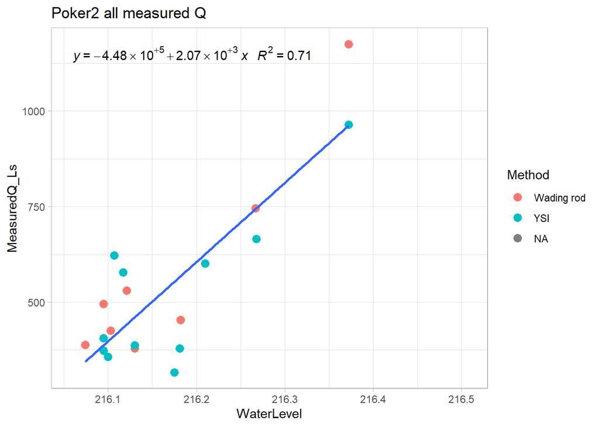

1) Removed highest YSI and 2) Removed lowest Wading rods

### Predicted Q for POKE PT1

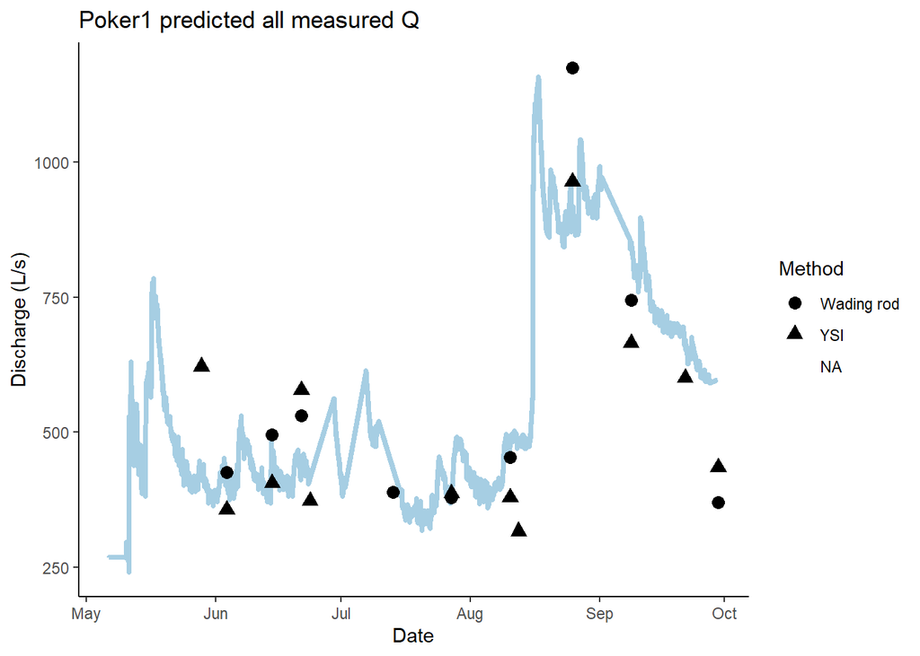

Not the prettiest thing I have ever seen

### Predicted Q for POKE PT2

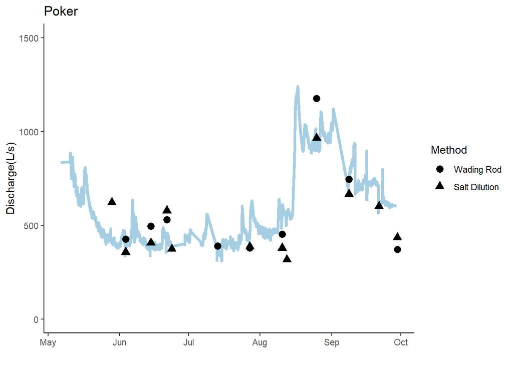

Looks better then PT1…snowmelt signature looks good

### Average Q for POKE

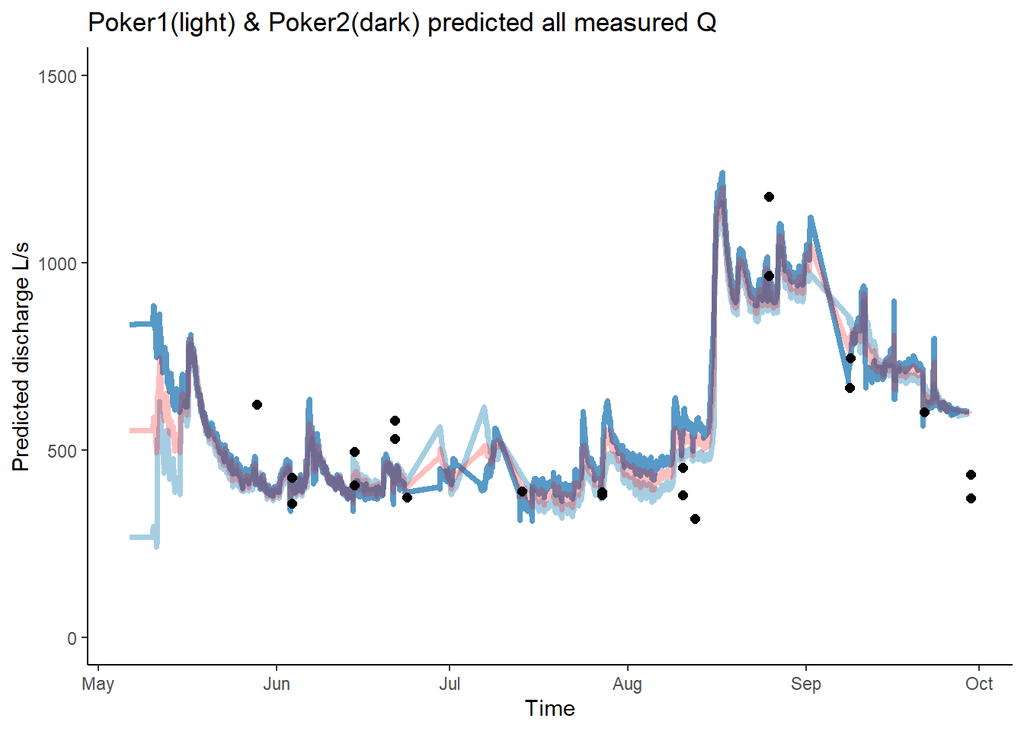

I think I should clip off the beginning of PT1 as the snowmelt signature makes more sense in PT2…what do you think?

## Export PT data to csv in DoD_Discharge->Predicted_discharge->2021

### Raw Vault PT1

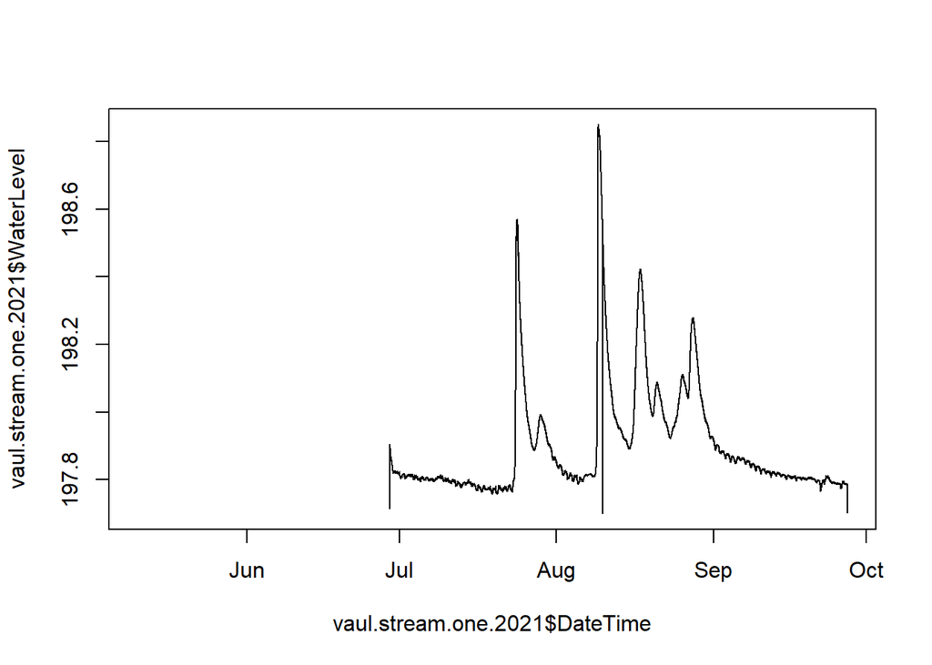

Need to remove vertical bars associated with out of water points such as the beginning and the end of the dataframe

### Vault PT1 2.0

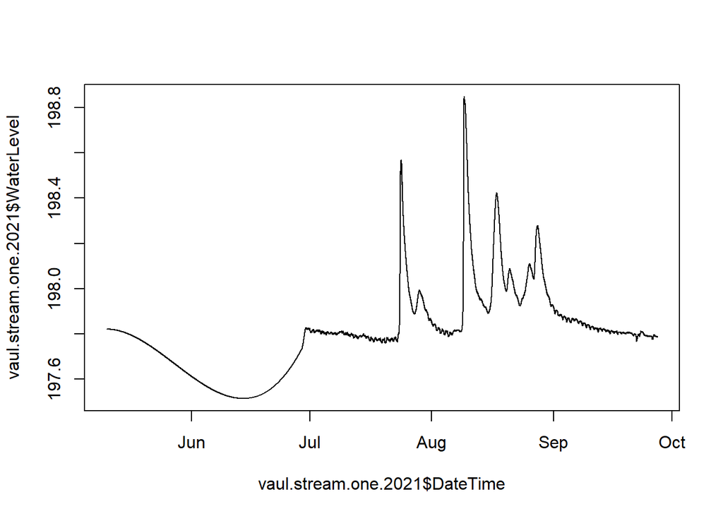

1) Removed vertical bars errant points in the beginning of the dataframe as well the middle of the first big storm and the end of the dataframe

## Export PT data to csv in DoD_Discharge->PT_data->2021

### Raw VAUL rating curve

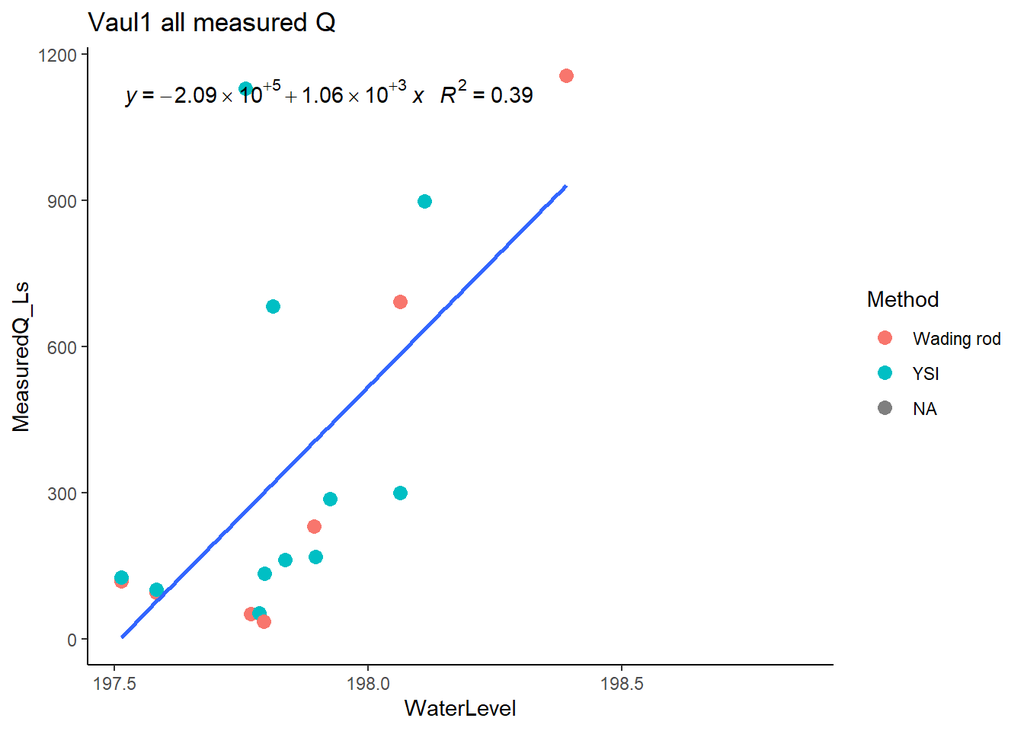

### Predicted Q for VAUL

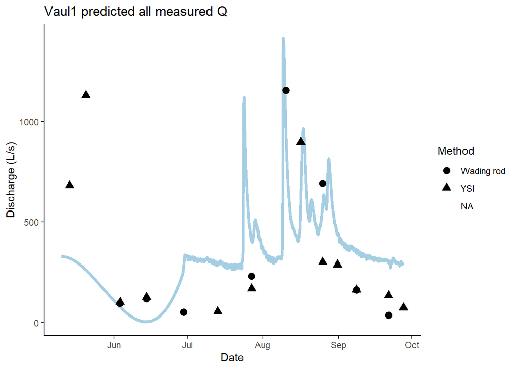

Not too shabby

## Export PT data to csv in DoD_Discharge->Predicted_discharge->2021

### Raw STRT PT1

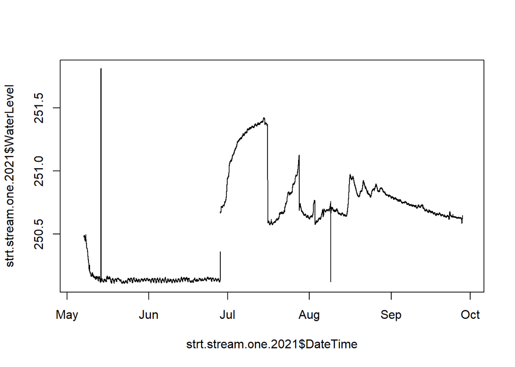

Need to shift beginning of dataframe up and remove beaverr dam in July…remove errant vertical bars

### STRT PT1 2.0

```
## [1] 0.543
```

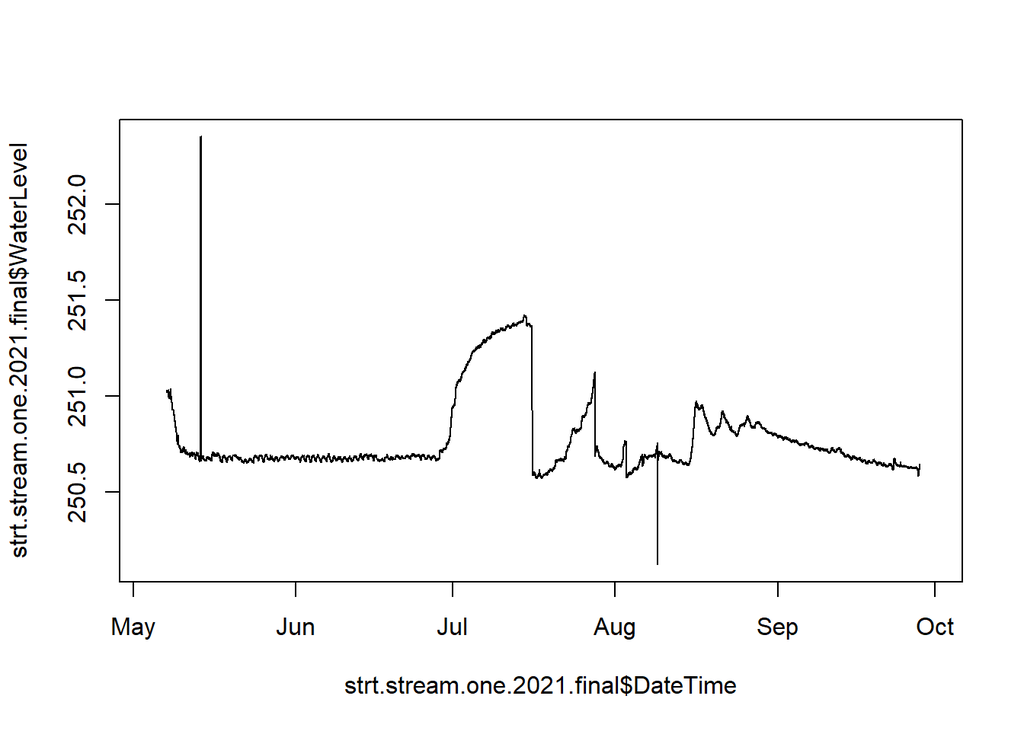

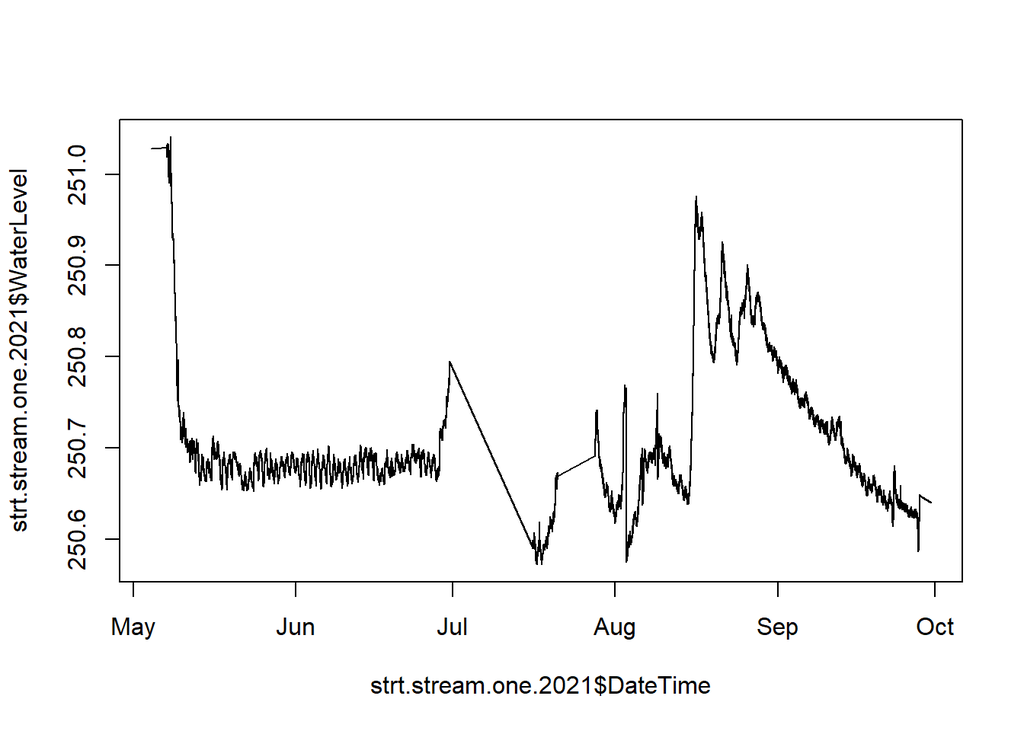

1) Removed errant vertical bar points 2)Removed beaver dam raises in Water level Quick snowmelt period and then not a lot of waterlevel change in June.

### Raw STRT PT2

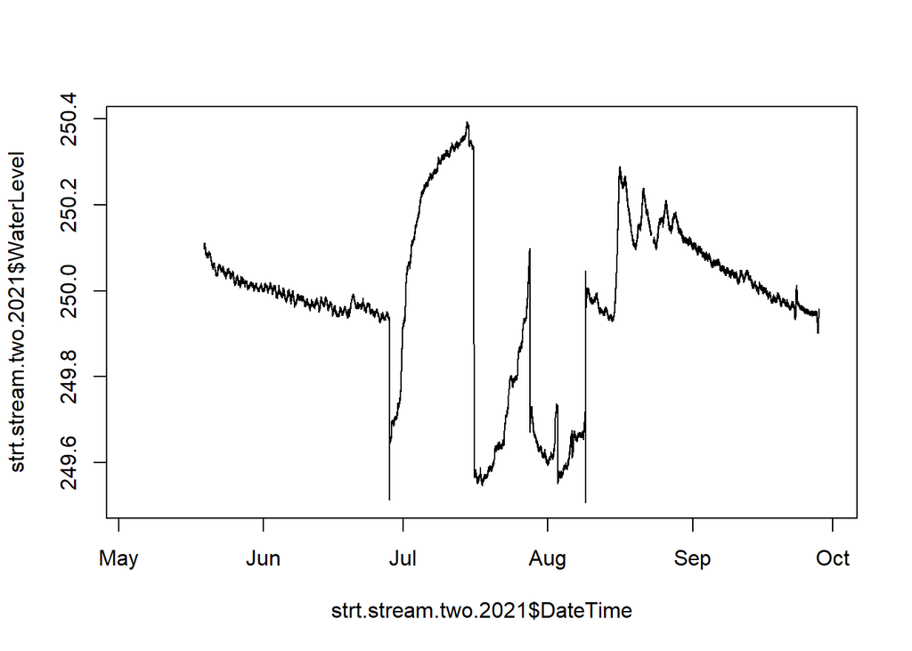

### STRT PT2 2.0

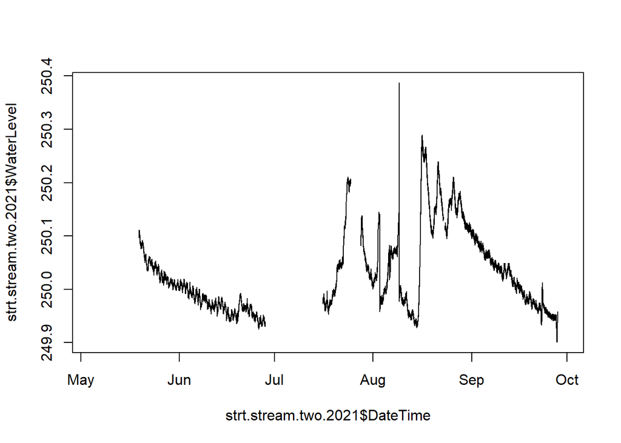

## Export PT data to csv in DoD_Discharge->PT_data->2021

### Raw STRT rating curve

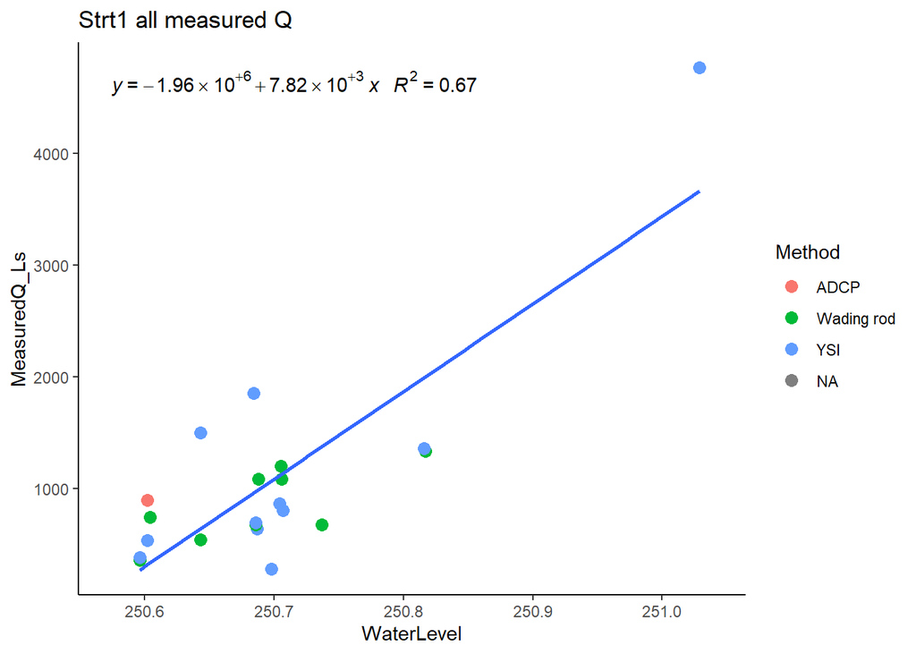

### STRT rating curve 2.0

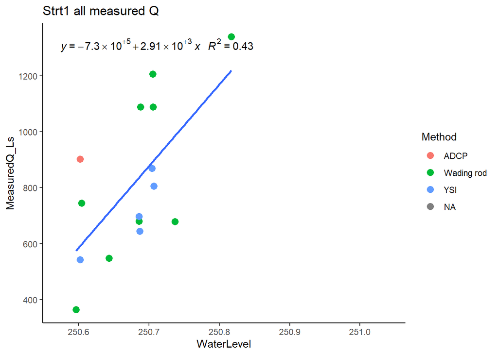

1) Removed highest and lowest YSIs

### Raw STRT rating curve PT2

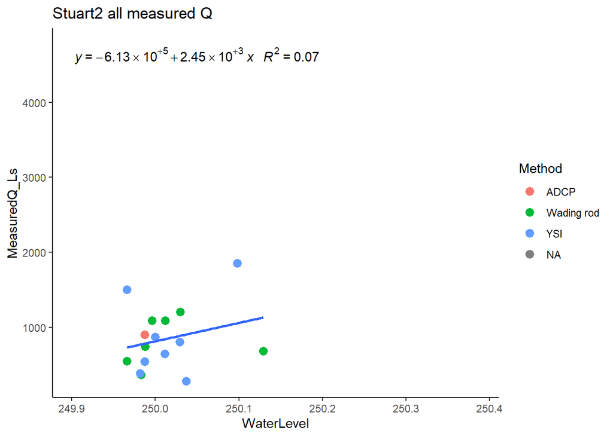

### STRT rating curve PT2 2.0

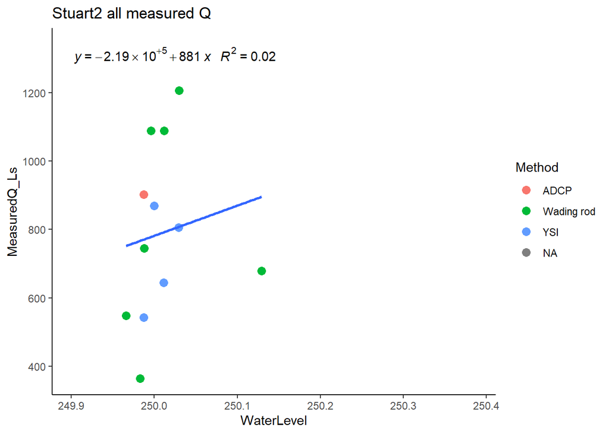

1)Removed lowest and highest YSIs Not as good as PT1

### Predicted Q STRT PT1

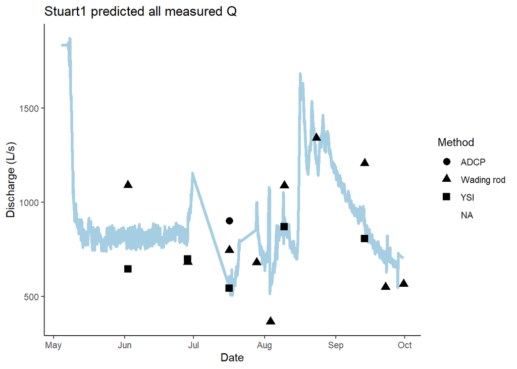

Icky

### Predicted Q STRT PT2

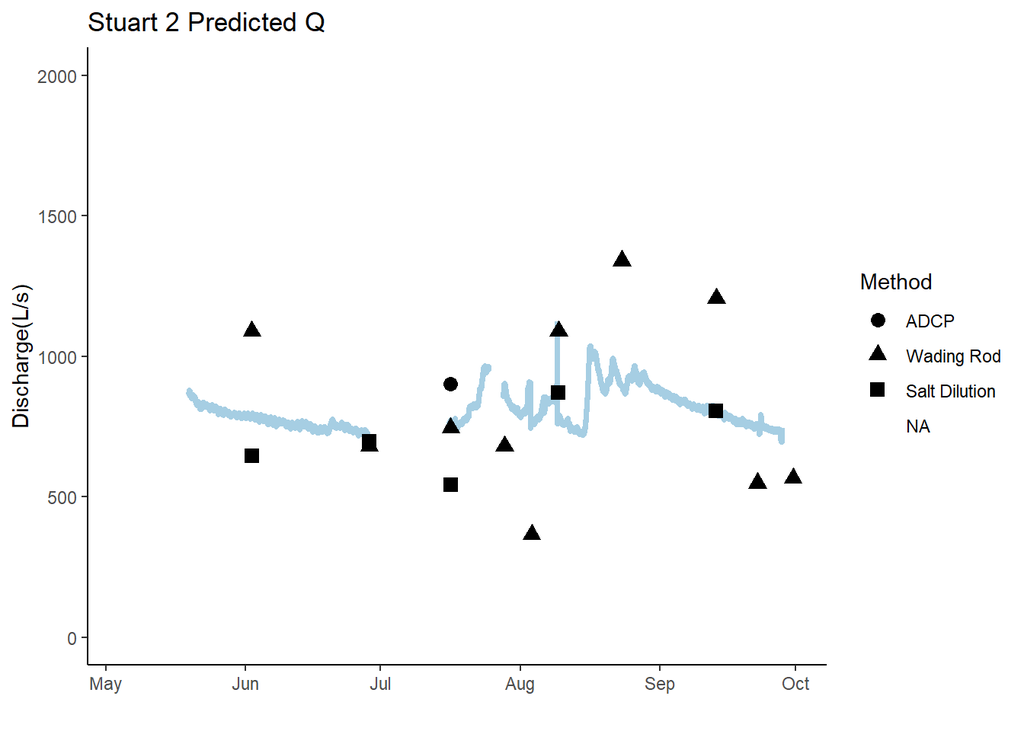

Icky

### Average Q for STRT

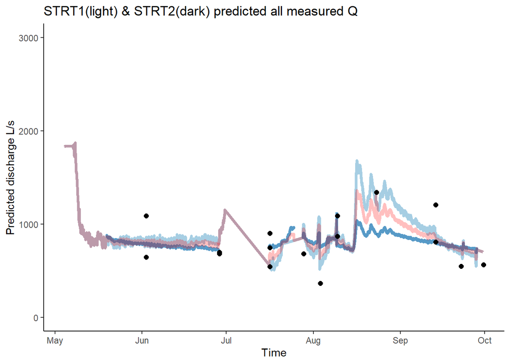

ICKY

## Export PT data to csv in DoD_Discharge->Predicted_discharge->2021

## Export PT data to csv in DoD_Discharge->Predicted_discharge->2021

### Average Q for STRT

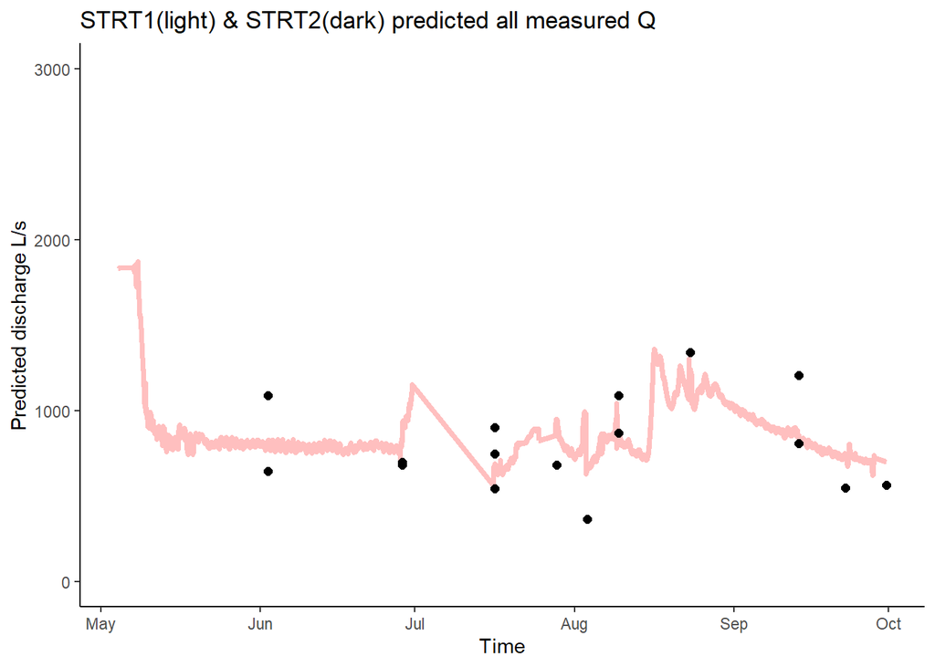